# Ecological Models and Data Analysis – Chapter 4, Lecture 2 — Ecological Models and Data Analysis

## Ecological Models and Data Analysis

Chapter 4 · Lecture 2

Maximum Likelihood Estimation: Uncertainty, Properties and Model Comparison

## Overview of the lecture

1. **Standard errors:** how precise is an estimate?
2. **Wald intervals:** what do we get from the curvature?
3. **Likelihood profile intervals:** which values do the data support?
4. **Coverage:** do the intervals do what they promise?
5. **Properties:** why does the method work, and when does it fail?
6. **Properties in R:** how do we check them by simulation?
7. **Model comparison:** which model do the data support?
8. **The practical:** what comes next?

## Recap: the steps of a fit

1. **Write the model:** the random variable, its distribution, the assumptions.
2. **Write the NLL:** two lists, `getAll()`, `log = TRUE`, transformations.
3. **Connect and process it:** `cmb()` and `MakeADFun()`.
4. **Minimise it:** `optim()`, and check `convergence`.
5. **Transform back:** and compare with the data.

Fir seedlings, 50 quadrats: $\hat\lambda=2.14$ seedlings per quadrat. Owls: $\hat\mu\approx4.75$ calls per visit, $\hat k\approx0.33$.

Today: how uncertain, why it works, which model.

## Uncertainty from the likelihood

### Wald interval

The curvature of the log-likelihood at its maximum, and asymptotic normality. Fast; what software usually reports.

### Likelihood profile interval

The whole shape around the maximum. The reference method; it needs many fits.

Both work for any parameter of any model estimated via maximum likelihood.

## Asymptotic normality of the MLE

$$\hat\theta \overset{\mathrm{approx}}{\sim}
\operatorname{Normal}\left(\theta,\operatorname{SE}(\hat\theta)^2\right)
\quad\text{for sufficiently large }n$$

- **Several parameters:** a multivariate Normal (Chapter 2), with a covariance matrix.
- **Wald interval:** $\hat\theta\pm1.96\,\widehat{\operatorname{SE}}(\hat\theta)$, as in Chapter 3.
- **Conditions:** not on the boundary of its range; support independent of the parameter; smooth log-likelihood; number of parameters does not grow with $n$.

Poisson mean: $\operatorname{Normal}(\lambda,\lambda/n)$, the result of Chapter 3.

## Curvature and standard errors

$$\ell(\theta)-\ell(\hat\theta)\approx
-\frac{(\theta-\hat\theta)^2}{2\,\widehat{\operatorname{SE}}(\hat\theta)^2}$$

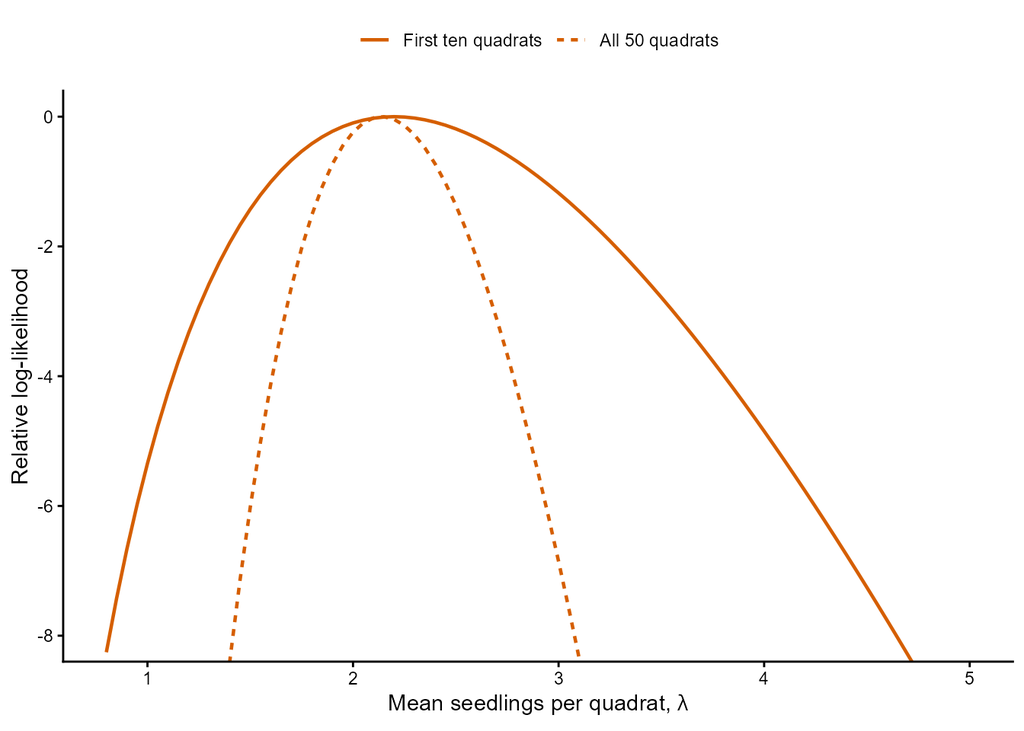

- **Large sample:** near its maximum, the log-likelihood is close to a parabola.
- **Falls slowly:** low curvature, many values supported, large standard error.
- **One parameter:** standard error = $1/\sqrt{\text{curvature}}$.
- **Several:** the curvatures give the covariance matrix.

Standard error of $\hat\lambda$: ten quadrats, 0.47; 50 quadrats, 0.207 seedlings per quadrat.

Relative log-likelihood of the same Poisson model. Solid: the first ten quadrats. Dotted: all 50.

## `sdreport()`: standard errors and correlations

- **`sdreport(obj)`:** after the fit; the curvature at the estimates.
- **`summary()`:** a row per parameter, with `Estimate` and `Std. Error`, on the optimised scale.
- **`cov.fixed`:** the covariance matrix; `cov2cor()` gives the correlations.
- **Tilted contours:** correlated estimates.

```r
# Standard errors after the fit of the owl model.
owl_sd = sdreport(owl_obj)
summary(owl_sd)
#        Estimate Std. Error
# log_mu    1.559      0.164
# log_k    -1.116      0.165

# Correlation between the two estimates.
cov2cor(owl_sd$cov.fixed)  # about 0
```

Correlation of the estimates: $\log(\mu)$ and $\log(k)$, about 0; $\log(k)$ and $\operatorname{logit}(p)$, 0.71, the tilt of the surface in Lecture 1.

## Back-transforming a standard error

`sdreport()` gives the standard error on the scale that was optimised.

### A non-linear function and an average

For a non-linear $g$: $E[g(X)]\neq g(E[X])$.

A variance is an average and a standard error its square root, so applying $g$ to them gives no standard error. Estimates and endpoints are values: they transform.

### The delta method

Treats $g$ as a straight line near the estimate: an approximation (Chapter 6).

`ADREPORT(k)` in the NLL: `sdreport()` adds a row with the standard error of $k$.

Ten quadrats (Poisson): `log_lambda`: 0.79 (0.21). `exp(log_lambda)`: 2.2 (1.24) but from the formula we know std error of $\hat\lambda$ is 0.47.

Transform estimates and endpoints; for a standard error on the new scale, use `ADREPORT()`.

## A Wald interval depends on the scale

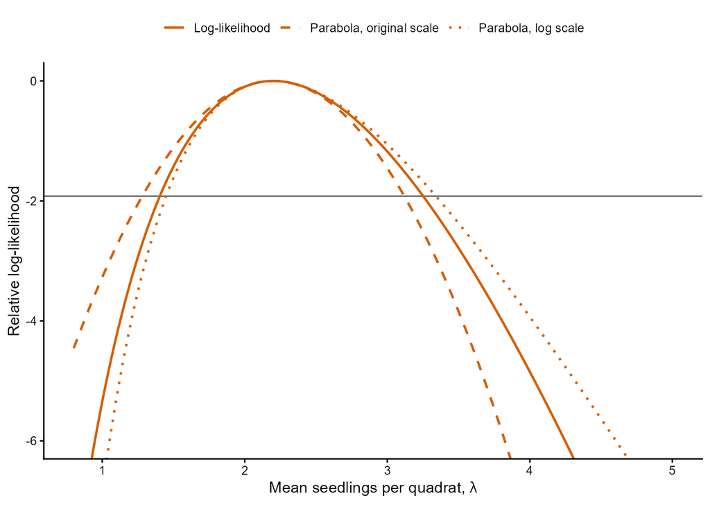

- **Wald interval:** replaces the log-likelihood by a parabola.
- **Optimised scale:** an unconstrained parameter is closer to Normal; calculate it there.
- **Endpoints:** an increasing transformation keeps the coverage.
- **Positive parameter:** stays positive, and asymmetry is captured.

Ten quadrats: 1.28 to 3.12 on the original scale; 1.45 to 3.34 from the log scale. Owls, $k$: 0.221 to 0.434; 0.237 to 0.453.

Solid: the log-likelihood. Dashed and dotted: parabolas on the original and the log scale. Grey line: $-1.92$.

## Practice 3: an interval from the log scale

**2 minutes:** R as a calculator.

A fit on the log scale returned `par = 0.92` for the logarithm of the mean number of ticks per lizard, and `sdreport()` reports a standard error of 0.141.

1. Calculate a 95% Wald interval for the mean number of ticks per lizard.
2. Why is it not symmetric around the estimate?

## Likelihood profile intervals

**Likelihood profile interval:** the values whose relative profile log-likelihoods are 1.92 units from the maximum.

- **1.92:** half the 0.95 quantile of a chi-squared distribution with one degree of freedom ($1.92 = 1.96^2/2$).

```r
qchisq(p = 0.95, df = 1) / 2  # 1.92
```

- **Wilks’ theorem:** explains why the chi-squared distribution comes from and relationship to asymptotic normality (same regularity conditions apply).

## Reading a likelihood profile interval

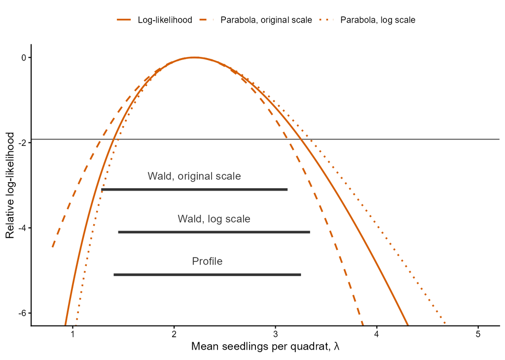

- **Shape:** the interval follows the curve, so it need not be symmetric.
- **Scale:** it does not depend on it.
- **Inner fits:** move the parameter, re-estimate the others, record the NLL, find the two crossings of the cutoff.
- **Larger sample:** closer to a parabola, so the intervals agree.

Ten quadrats: profile 1.40 to 3.25. With all 50 the three intervals nearly coincide.

95% intervals: Wald on the original scale, 1.28 to 3.12; Wald from the log scale, 1.45 to 3.34; profile, 1.40 to 3.25.

## `tmbprofile()` and `confint()`

- **`TMB::tmbprofile(obj, name, trace = FALSE)`:** profiles one parameter, named as in the list of parameters; returns a data frame.
- **`confint()`:** finds the two crossings of the cutoff.
- **Both on the optimised scale:** transform the endpoints back.

```r
# Ten quadrats: 1.40 to 3.25 seedlings per quadrat.
fir_ten_profile = TMB::tmbprofile(fir_ten_obj, name = "log_lambda", trace = FALSE)
exp(confint(fir_ten_profile))

# Owls: k from 0.235 to 0.451.
owl_profile_k = TMB::tmbprofile(owl_obj, name = "log_k", trace = FALSE)
exp(confint(owl_profile_k))
```

## Profile intervals with several parameters

- **Each parameter:** its own profile, with the others re-estimated.
- **Wald, optimised scale:** can come close.
- **Wald, original scale:** may miss the asymmetry.
- **The reference:** the likelihood profile interval.

[output not shown]

## Joint confidence regions

**Joint confidence region:** the combinations whose relative log-likelihood is above a cutoff; 3.00 for two parameters (half the 0.95 quantile with two degrees of freedom).

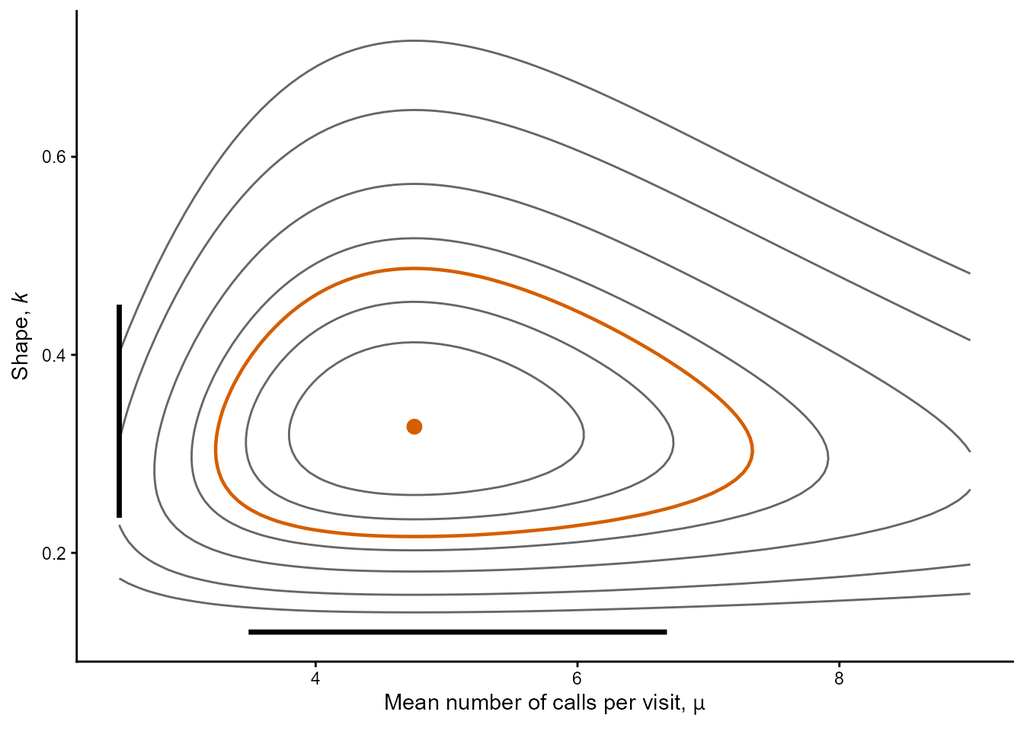

- **The region:** lies inside one contour of the surface.
- **Beyond each interval:** it extends further than either.
- **The rectangle** of two intervals is not a 95% region.
- **Use:** an interval for one parameter, a region for a combination.

The owl model. Vermillion contour: the region. Segments on the axes: the two profile intervals.

## Simulating from a fitted model

- **`OBS()`** in the NLL: marks the data as observations.
- **`obj$simulate()`:** draws a hypothetical sample of the size of the data, for parameters on the optimised scale.
- **Placeholder data** of another length: give another sample size.

```r
# The complete NLL of the Negative Binomial model.
nb_nll = function(parms, data) {
  getAll(parms, data)
  # Mark the data as observations, so that they can be simulated.
  calls = OBS(calls)
  mu = exp(log_mu)
  k = exp(log_k)
  ADREPORT(k)
  -sum(dnbinom2(x = calls, mu = mu, size = k, log = TRUE))
}
# After processing and fitting: the first 20 counts of one hypothetical sample.
owl_obj$simulate(owl_fit$par)$calls[1:20]
```

## Coverage of Wald and profile intervals

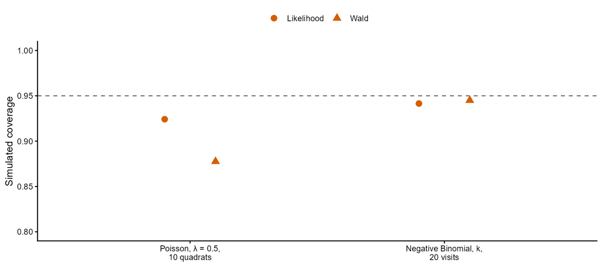

Dashed line: the nominal level. Likelihood: the likelihood profile interval. Poisson: Wald on the original scale. Negative Binomial: Wald from the log scale.

- **Simulate** from known parameters: does each interval contain them?
- **Wald, original scale:** fails where the log-likelihood is far from a parabola.
- **Wald, suitable scale:** can match the profile, with one fit.
- **Simulated coverage:** has its own noise.

Wald 0.878 and profile 0.924 (Poisson); 0.945 and 0.942 (Negative Binomial).

Profile intervals: closer to 95% in small samples, at the cost of many fits. Wald on the log scale: the fast approximation.

## Discussion: Wald or profile?

1. Uses the curvature at the maximum.
2. Gives the same interval on any scale.
3. Needs a single fit.
4. Can include negative values for a positive parameter.

Wald · Profile

**1 minute:** decide with a neighbour.

## Consistency and asymptotic normality

**Consistent estimator:** the chance of missing the parameter by more than any given margin becomes small as the sample grows.

- **An MLE is an estimator:** it has a sampling distribution, a bias and a variance.
- **MLEs are consistent:** when the observations are i.i.d. from the model; a statement about probabilities, not about every sample.
- **Normal approximation:** how large $n$ must be depends on the model and the parameter.
- **Large $n$:** the standard error of one fit describes the spread across samples.

Missing $k$ by 0.1 or more: 45% with 20 visits, 7% with 122, none with 500.

## Efficiency

**More efficient:** estimates vary less across hypothetical samples.

- **Maximum likelihood:** uses the probability of each observation; the method of moments only the mean and the variance.
- **Asymptotically efficient:** in large samples no other regular estimator is more precise.
- **The limit:** the variance from the curvature of the log-likelihood is the smallest that such an estimator can have.

Standard deviation of $\hat k$: 122 visits, 0.055 against 0.086; 500 visits, 0.024 against 0.042. The method of moments would need about 2.5 times as many visits.

The reason to use maximum likelihood whenever the likelihood can be written.

## Bias in finite samples

- **MLEs:** in general biased in finite samples.
- **The bias:** shrinks as the sample grows, faster than the standard error.
- **Small sample:** these properties are approximations.
- **Check by simulation:** simulate hypothetical samples from the fit, refit each, and compare the mean of the estimates with the value used to simulate.

Relative bias of $\hat k$: 21%, 2.6% and 0.6% for 20, 122 and 500 visits.

## Live demo: properties by simulation

1. **One hypothetical sample:** `obj$simulate()` at the estimates, fitted like the data.
2. **Many samples:** placeholder data set the sample size; keep every estimate.
3. **Sampling distributions:** a histogram of the estimates for each sample size.
4. **Properties:** consistency, the standard error, efficiency and bias from the estimates.

**Script:** `demo-properties.R`, sections 1 to 4 (the owl model; section 3 runs for about a minute).

## Misspecified models

**Misspecified:** the model does not contain the distribution of the data generating process, for any parameter values.

- **The MLE:** converges to the values that bring the model closest to that process (the Kullback–Leibler divergence).
- **The fit:** the best approximation that the model offers.
- **Standard errors and intervals:** become approximations.

## The Akaike information criterion

$$\mathrm{AIC}=2K-2\,\ell(\hat\theta)$$

- **$K$:** the number of estimated parameters.
- **More parameters:** more freedom to adapt to its own sample; when a model contains another as a special case, its maximum cannot be lower.
- **Lowest AIC:** preferred; only differences between models fitted to the same observations in the same units are meaningful.
- **It estimates:** the distance to the data generating process when predicting new data.
- **AICc:** adds $2K(K+1)/(n-K-1)$ for small samples; an approximation.

Owls: Poisson, $K=1$, $\ell=-634.16$, AIC = 1270.

Negative Binomial, $K=2$, $\ell=-299.44$, AIC = 603.

## Using AIC

- **It ranks** the candidates that we give it.
- **It does not show** that the best one describes the data well.
- **“Reject unless AIC drops by two units”:** null hypothesis testing in disguise.
- **One criterion among others:** for evidence and prediction.

Negative Binomial far better than Poisson for the owls, and still an approximation (visits to the same nest).

## Practice 4: waiting for a pollinator

**2 minutes:** on paper.

An Exponential model ($K=1$) and a Gamma model ($K=2$) are fitted to the same waiting times between visits of pollinators to a flower. The maximum log-likelihoods are $-231.0$ and $-230.4$.

1. Calculate the AIC of both models. Which one is lower?
2. Could the log-likelihood of the Gamma model have been the lower of the two?

## A recipe for a fit

1. **Write the model:** random variable, distribution, assumptions.
2. **Write the NLL:** `getAll()`, `log = TRUE`, transformations.
3. **Connect and process it:** `cmb()`, `MakeADFun()`, starting values.
4. **Minimise it:** `optim()`, `method = "BFGS"`, check `convergence`.
5. **Transform back:** compare the fitted model with the data.
6. **Standard errors and Wald intervals:** `sdreport()`, `ADREPORT()`.
7. **Likelihood profile intervals:** `TMB::tmbprofile()`, `confint()`.
8. **Compare the candidates:** AIC.

The same steps for every model in the rest of the book.

## The Chapter 4 R practical

- **Reed frog tadpoles** (Exercise 1, questions 3 to 6): standard errors, intervals, adequacy, predators.
- **Glacier lily seedlings** (Exercise 2): joint region, intervals, AIC.
- **Zero inflation** (Exercise 3).
- **Timber volume** (Exercise 4): Gamma model, slice and profile.
- **Simulation** (Exercise 5): extra.

Exercises 1 to 4 are the core. Try, then check.

## Summary and closing questions

- In large samples an MLE is approximately Normal, with a covariance matrix from the curvature of the log-likelihood.
- `sdreport()` gives standard errors on the optimised scale; endpoints transform back, standard errors need `ADREPORT()`.
- Profile intervals follow the likelihood and do not depend on the scale.
- Simulation checks coverage and the properties of estimators.
- MLEs are consistent and asymptotically efficient, and biased in small samples.
- AIC ranks candidates and shows nothing about whether they are good.

Curvature · Standard errors · Wald · Profile · Coverage · Efficiency · AIC

**Closing questions**

1. Why can we transform the endpoints of an interval and not a standard error?
2. What does AIC not tell us?